# TP à faire par groupe de 3

Kalidou BA (kalidou.ba@u-bordeaux.fr)

03 Octobre 2023

### PARTIE I : Les base de l’ACP sur les données simulées

1. Simuler $n=10$ réalisations de A à J de trois variables aléatoires $x$, $y$ et $z$ suivant une loi normale d’espérance $(5,2,8)$ et de matrice de covariance $\Sigma = \begin{vmatrix} 14 & 4 & 2\\ 7 & 9 & 6\\ 12 & 3 & 5 \end{vmatrix}$ (Vous utiliserez la fonction $mvrnorm()$)

```r
n <- 10
moys <- c(5, 2, 8)
sigmas <- matrix(c(14, 4, 2, 7, 9, 6, 12, 3, 5), ncol = 3)
simulate_data <- MASS::mvrnorm(n = n, mu = moys, Sigma = sigmas)
dimnames(simulate_data) <- list(LETTERS[1:10], c("x", "y", "z"))
simulate_data <- as.data.frame(simulate_data)
```

2. Calculer le tableau centré réduit $simulate\_data\_CR$

```r
moyennes <- colMeans(simulate_data)
ecart_types <- apply(simulate_data, 2, sd)
simulate_data_CR <- as.data.frame(scale(simulate_data, center = moyennes, scale = ecart_types))

print(simulate_data_CR)
```

```
##             x          y          z
## A  0.13290485 -0.5684027 -1.1017519
## B -1.20328660 -0.1368727  0.4783030
## C -0.02846121  0.3651751  0.5894308
## D  0.53226858 -1.4180175 -1.3626478
## E -1.07955584 -0.7336943 -0.5931422
## F -0.62755025 -0.1988382 -0.1114724
## G -0.98976373 -0.7161199 -1.1526424
## H  1.96759738  2.0204149  1.3140027
## I  0.63420315  1.1292505  1.1312896
## J  0.66164367  0.2571048  0.8086306
```

3. Calculer le centre de gravité $Cg$ du nuage de points en utilisant la fonction $apply()$

```r
Cg <- apply(simulate_data_CR, 2, mean)
print(Cg)
```

```
##             x             y             z
## -1.689946e-16 -5.827045e-17  2.927888e-16
```

4. Calculer la matrice d’inertie S du jeu de données $simulate\_data\_CR$

```r
matrice_inertie <- cov(simulate_data_CR)
print(matrice_inertie)
```

```
##           x         y         z
## x 1.0000000 0.6456975 0.4694461
## y 0.6456975 1.0000000 0.9034777
## z 0.4694461 0.9034777 1.0000000
```

5. Quelle est l’inertie du nuage calculée par la trace de sa matrice d’inertie?

```r
inertie <- sum(diag(matrice_inertie))
print(inertie)
```

```
## [1] 3
```

6. Déterminer les valeurs propres et les vecteurs propres de la matrice d’inertie à l’aide de la fonction $eigen()$.

```r
valeurs_propres <- eigen(matrice_inertie)$values
vecteurs_propres <- eigen(matrice_inertie)$vectors
deux_premiers_vecteurs <- vecteurs_propres[, 1:2]
deux_premiers_vecteurs
```

```
##           [,1]       [,2]
## [1,] 0.5026760  0.8396553
## [2,] 0.6305152 -0.1933517
## [3,] 0.5914115 -0.5075373
```

7. Quelle est la contribution absolue de l’axe F1 à l’inertie du nuage de point ?

```r
inertie_totale <- sum(valeurs_propres)
contribution_absolue_F1 <- (valeurs_propres[1] / inertie_totale) * 100

print(contribution_absolue_F1)
```

```
## [1] 78.74084
```

8. Définir la qualité de représentation des mesures A, B, C et D sur l’axe F1. Pour ce faire calculer les coordonnées des projections des observations A, B, C et D sur l’axe F1 puis définir les qualités
   $$QR (i | F1) = \frac{Projection\ de\ i\ sur\
   l’axe\ F1}{Inertie\ totale}$$
   avec

$$Projection\ de\ i\ sur\ l’axe\ F1 =
Coordonnées\ de\ i × Vecteur\ propre\ de\ l’axe\ F1$$

```r
coordonnees_A_D <- simulate_data_CR[1:4,]
vecteur_propre_F1 <- valeurs_propres[1]

# Calcul de la projection de A,B,C et D sur l'axe F1
projection_A_D_F1 <- rowSums(coordonnees_A_D * vecteur_propre_F1)
projection_A_D_F1/inertie
```

```
##          A          B          C          D
## -1.2104434 -0.6786329  0.7292542 -1.7704065
```

### PARTIE II : ACP sur la génomique sur les poulets

9. Importer dans un objet poulet le jeu de données poulet.csv avec la fonction $read.csv()$. Mettre les gènes en colonne.

```r
poulet <- read.csv("poulet.csv",header=TRUE,sep=";",dec=".",row.names=1)
poulet <- as.data.frame(t(poulet))
dim(poulet)
```

```
## [1]   43 7406
```

10. Créer une nouvelle variable catégorielle $regime$ qui prend les modalités $N,\ J16,\ J16R5,\ J16R16,\ J48,\ J48R24$ avec les effectifs respectifs 6, 5, 8, 9, 6 et 9.

```r
regime <- as.factor(c(rep("N",6),rep("J16",5),rep("J16R5",8),rep("J16R16",9),rep("J48",6),rep("J48R24",9)))
poulet <- cbind.data.frame("Régime" = regime,poulet)
dim(poulet)
```

```
## [1]   43 7407
```

11. À l’aide du package FactoMineR effectuer une analyse des composantes principales sur le jeu de données centré et normalisé

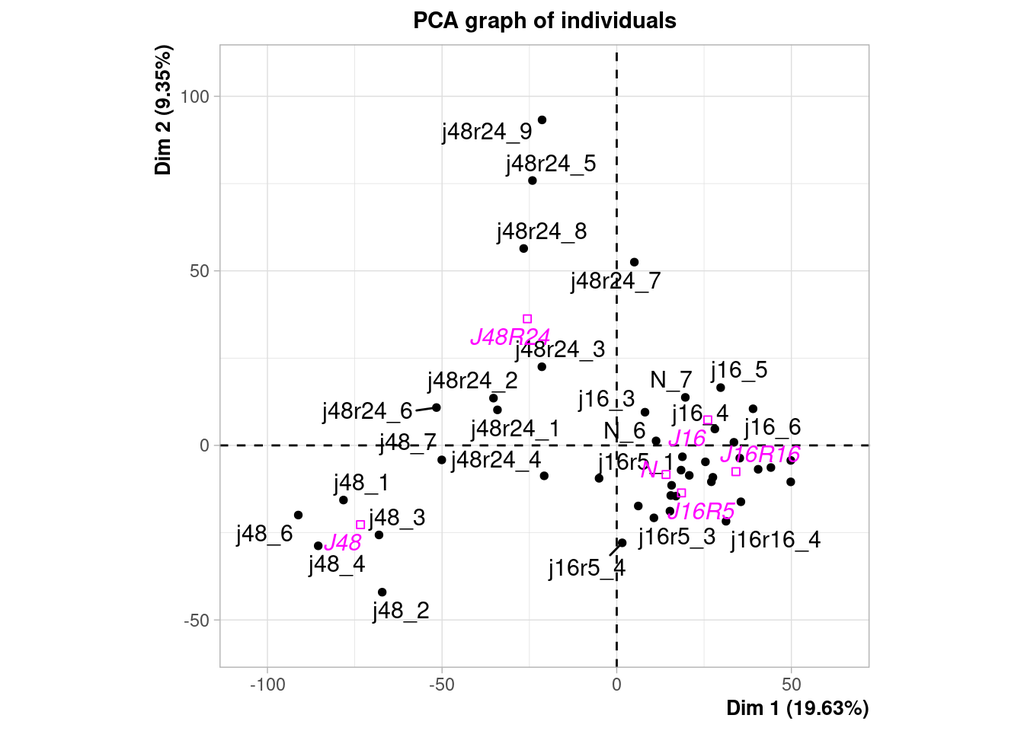

[figure not shown]

```r
library(FactoMineR)
res.pca <- PCA(poulet,quali.sup=1)
```

12. Representer graphiquement la variation des valeurs propres et proposer un nombre de composants à retenir.

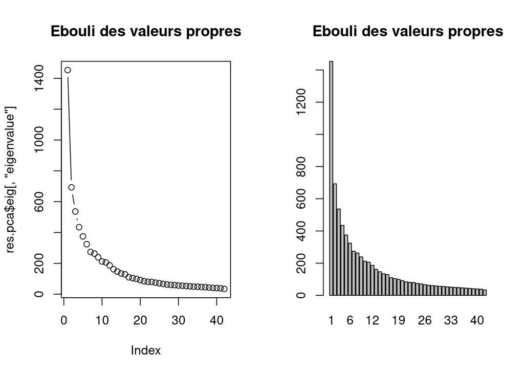

```r
par(mfrow=c(1,2))
plot(res.pca$eig[,"eigenvalue"], type = 'b',
     main="Ebouli des valeurs propres")
barplot(res.pca$eig[,"eigenvalue"],
        main="Ebouli des valeurs propres",
        names.arg=1:nrow(res.pca$eig))
```

13. Choisir le nombre de facteurs obtenu par la règle de Kaiser (On séléctionne les vecteurs/valeurs propres uniquement supérieurs à l’inertie moyenne)

```r
eig_value <- res.pca$eig[,"eigenvalue"]
inertieMoyenne <- mean(eig_value)
select_eig_value <- eig_value[eig_value >= inertieMoyenne]
select_eig_value
```

```
##    comp 1    comp 2    comp 3    comp 4    comp 5    comp 6    comp 7    comp 8
## 1453.5724  692.7879  536.2080  434.4534  374.6216  324.0825  273.7982  263.2310
##    comp 9   comp 10   comp 11   comp 12
##  238.8273  212.2264  205.8686  186.6881
```

14. Visualiser des individus sur le premier plan factoriel.

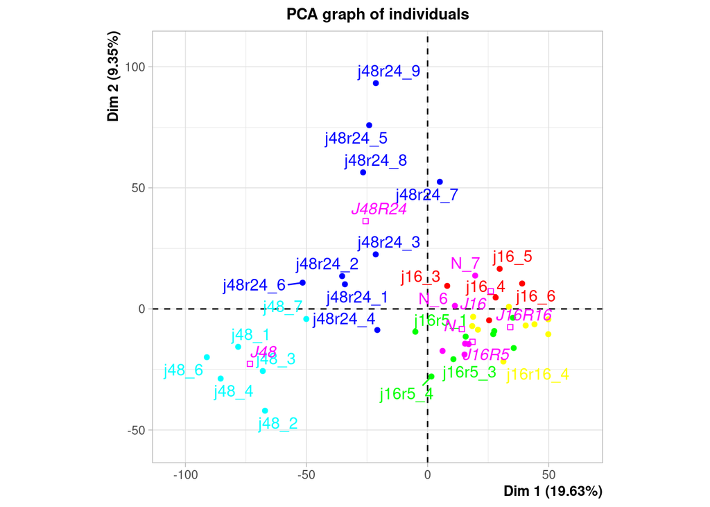

```r
plot(res.pca, choix = "ind", habillage = "ind",
     col.hab=rainbow(6)[poulet$Régime])
```

============================================================================================================

### Nombre de personnes dans le bus

15. Un bus se déplace en ville, il prend et/ou dépose certaines personnes à chaque arrêt. Vous recevez une liste d’entiers. Chaque élément comporte le nombre de personnes qui montent dans le bus (le premier élément) et le nombre de personnes qui en sortent (le deuxième élément). Le 2e nombre du premier élément de la liste vaut toujours 0 car le bus est vide en arrivant au premier arrêt de bus. Votre tâche consiste à renvoyer le nombre de personnes encore dans le bus après le dernier arrêt. Vous pouvez utiliser comme entré de fonction une liste de vecteurs à deux éléments.

*number(list([10,0],[3,5],[5,8])) —> 5*

*number(list([3,0],[9,1],[4,10],[12,2],[6,1],[7,10])) —> 17*

*number(list([3,0],[9,1],[4,8],[12,2],[6,1],[7,8])) —> 21*

```r
number <- function(arg) {
  inBus <- 0
  outBus <- 0
  for (i in 1:length(arg)) {
    inBus <- inBus + arg[[i]][1]
    outBus <- outBus + arg[[i]][2]
  }
  return(inBus - outBus)
}
```

```r
# Exemple d'utilisation
arg1 <- list(c(10,0),c(3,5),c(5,8))
arg2 <- list(c(3,0),c(9,1),c(4,10),c(12,2),c(6,1),c(7,10))
arg3 <- list(c(3,0),c(9,1),c(4,8),c(12,2),c(6,1),c(7,8))

result1 <- number(arg1)
result2 <- number(arg2)
result3 <- number(arg3)

cat("Result 1:", result1, "\n")
```

```
## Result 1: 5
```

```r
cat("Result 2:", result2, "\n")
```

```
## Result 2: 17
```

```r
cat("Result 3:", result3, "\n")
```

```
## Result 3: 21
```

### Conversion du temps

16. Votre tâche est d’écrire une fonction qui écrit une durée, donnée en secondes, de façon conviviale. La fonction doit accepter un nombre entier positif ou nul. Si le nombre est nul, renvoyer simplement “now”. Sinon, la durée est exprimée sous la forme d’une combinaison d’années, de jours, d’heures, de minutes et de secondes.

#### Règles détaillées:

**Indications**

— Considérer une année, un jour, une heure et une minute dans leurs équivalents en secondes.

— Pour une valeur d’entrée positive, regardez le nombre d’années, de jours, ainsi de suite ….

— Utilisez la fonction *paste0()* pour gérer les pluriels et *paste()* pour obtenir le texte de sortie au bon format.

```r
formatDuration <- function(seconds) {
  time <- list(year = 31536000, day = 86400, hour = 3600, minute = 60, second = 1)
  res <- character(0)

  if (seconds == 0) {
    return("now")
  }

  for (key in names(time)) {
    if (seconds >= time[[key]]) {
      val <- floor(seconds / time[[key]])
      res <- c(res, paste(val, ifelse(val > 1, paste0(key, "s"), key)))
      seconds <- seconds %% time[[key]]
    }
  }

  if (length(res) > 1) {
    last_element <- res[length(res)]
    res[length(res)] <- paste("and", last_element)
    return(paste(res, collapse = ', '))
  } else {
    return(res[1])
  }
}
```

```r
# Exemple d'utilisation 1
seconds <- 62
formatted_duration <- formatDuration(seconds)
cat("Formatted Duration:", formatted_duration, "\n")
```

```
## Formatted Duration: 1 minute, and 2 seconds
```

```r
# Exemple d'utilisation 2
seconds <- 3662542
formatted_duration <- formatDuration(seconds)
cat("Formatted Duration:", formatted_duration, "\n")
```

```
## Formatted Duration: 42 days, 9 hours, 22 minutes, and 22 seconds
```